# Kümeleme Analizi

Yakup Tarık AÇAN

# Veri Hakkında

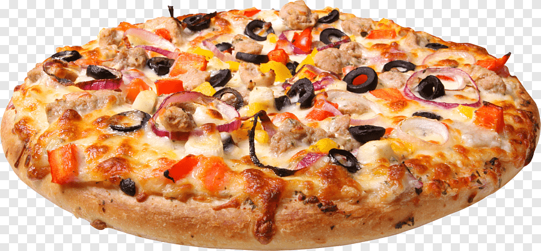

Verimiz 300 gözlemden oluşan 10 farklı pizza markasındaki değerleriden oluşmaktadır. Verimizin büyüklüğü çok yüksek olmadığından herhangi bir sampling işlemi yapılmamıştır. Değişkenlerimizin açıklaması aşağıdaki gibidir.

brand: pizza markaları (A,B,C,D,E,F,G,H,I,J) mois: örneklemdeki pizzanın 100 gramında bulunan su miktarı prot: örneklemdeki pizzanın 100 gramında bulunan protein miktarı ash: örneklemdeki pizzanın 100 gramında bulunan kül miktarı sodium: örneklemdeki pizzanın 100 gramında bulunan sodyum miktarı carb: örneklemdeki pizzanın 100 gramında bulunan karbonhidrat miktarı cal: örneklemdeki pizzanın 100 gramında bulunan kalori miktarı fat: örneklemdeki pizzanın 100 gramında bulunan yağ miktarı

NOT: Bütün analizlerde güven düzeyi %95 olarak alınmıştır.

## Veri Analizi

- Verimizin değişken özellikleri kontrol edilmiştir.

```r
str(pizza_marka)
```

```
## tibble [300 x 8] (S3: tbl_df/tbl/data.frame)
##  $ brand : chr [1:300] "A" "A" "A" "A" ...
##  $ mois  : num [1:300] 27.8 28.5 28.4 30.6 30.5 ...
##  $ prot  : num [1:300] 21.4 21.3 20 20.1 21.3 ...
##  $ ash   : num [1:300] 5.11 5.34 5.08 4.79 4.82 4.92 4.71 5.28 5.02 5.16 ...
##  $ sodium: num [1:300] 1.77 1.79 1.63 1.61 1.64 1.65 1.58 1.75 1.71 1.66 ...
##  $ carb  : num [1:300] 0.77 1.02 0.8 1.38 1.76 1.4 1.77 2.95 1.18 0.64 ...
##  $ cal   : num [1:300] 4.93 4.84 4.95 4.74 4.67 4.67 4.63 4.72 4.93 4.95 ...
##  $ fat   : num [1:300] 44.9 43.9 45.8 43.1 41.6 ...
```

```r
summary(pizza_marka)
```

```
##     brand                mois            prot            ash
##  Length:300         Min.   :25.00   Min.   : 6.98   Min.   :1.170
##  Class :character   1st Qu.:30.90   1st Qu.: 8.06   1st Qu.:1.450
##  Mode  :character   Median :43.30   Median :10.44   Median :2.225
##                     Mean   :40.90   Mean   :13.37   Mean   :2.633
##                     3rd Qu.:49.12   3rd Qu.:20.02   3rd Qu.:3.592
##                     Max.   :57.22   Max.   :28.48   Max.   :5.430
##      sodium            carb             cal             fat
##  Min.   :0.2500   Min.   : 0.510   Min.   :2.180   Min.   : 4.38
##  1st Qu.:0.4500   1st Qu.: 3.467   1st Qu.:2.910   1st Qu.:14.77
##  Median :0.4900   Median :23.245   Median :3.215   Median :17.14
##  Mean   :0.6694   Mean   :22.865   Mean   :3.271   Mean   :20.23
##  3rd Qu.:0.7025   3rd Qu.:41.337   3rd Qu.:3.520   3rd Qu.:21.43
##  Max.   :1.7900   Max.   :48.640   Max.   :5.080   Max.   :47.20
```

- Verimizde eksik gözlem kontrolü yapılmıştır ve eksik gözlem olmadığı görülmüştür.

```r
anyNA(pizza_marka)
```

```
## [1] FALSE
```

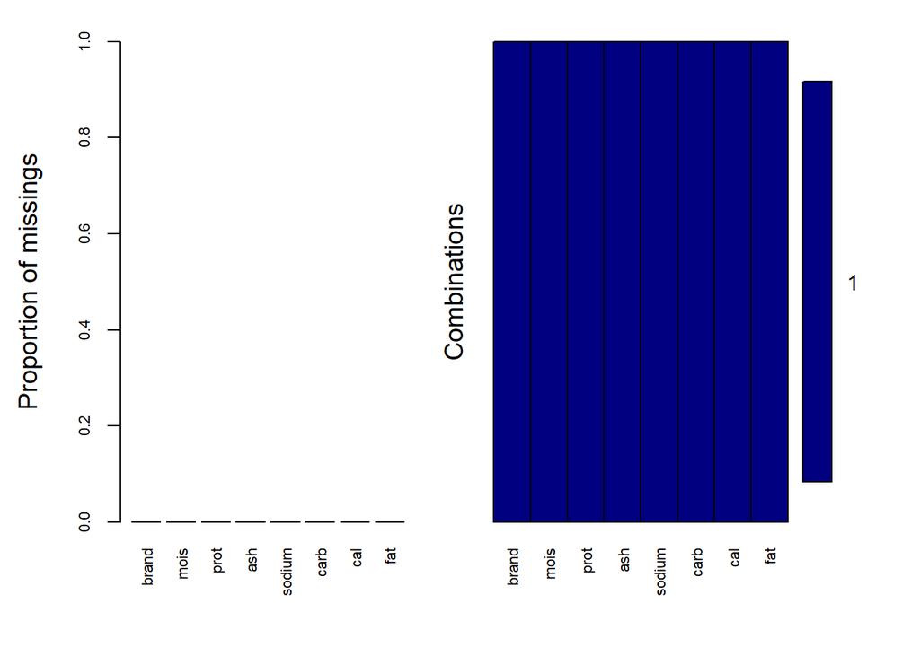

```
##
##  Variables sorted by number of missings:
##  Variable Count
##     brand     0
##      mois     0
##      prot     0
##       ash     0
##    sodium     0
##      carb     0
##       cal     0
##       fat     0
```

```r
plot2<-aggr(pizza_marka,col=c("navyblue","pink"),numbers=TRUE, sortVars=TRUE, labels=names(pizza_marka),cex.axis=.7,gap=3)
```

### Dendongram

**“Euclidean”** methodu kullanılarak çizilen dendogram incelenmiştir ve 4 kümeye bölünmesi karar verilmiştir ve buna göre renklendirilmiştir.

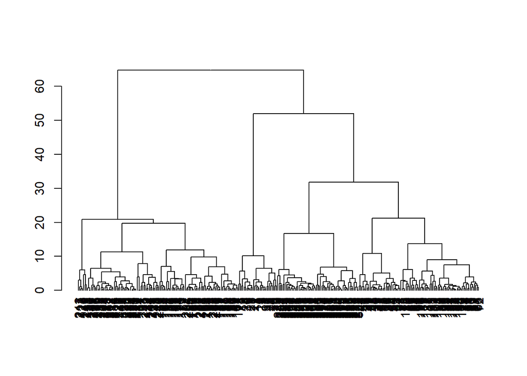

```r
d <- dist(pizza_marka[,c(-1)], method = "euclidean")
fit <- hclust(d, method="complete")
dend<-as.dendrogram(fit)
plot(dend)
```

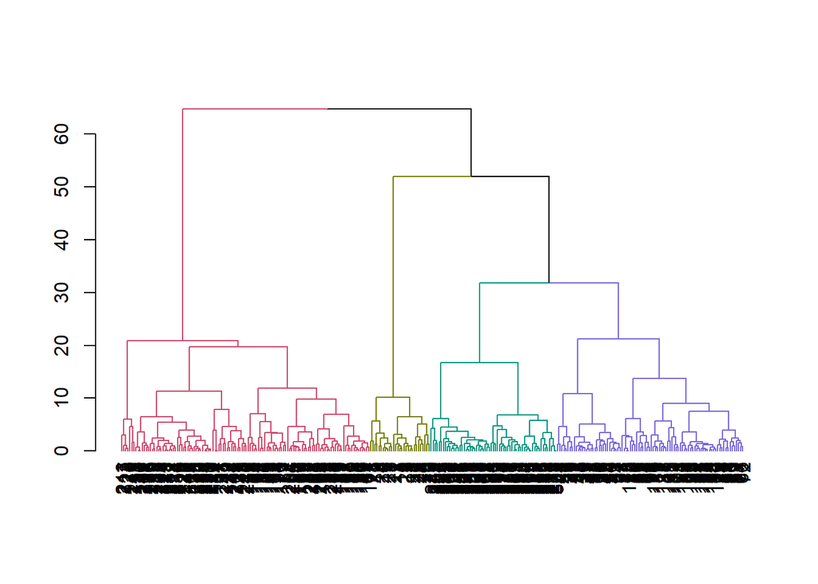

```r
plot(color_branches(dend, k=4))
```

### Scree Plot

4. kırılım daha önceki kırılımlara aykırı olduğu için küme sayımızı 4 olarak karar verilmiştir.

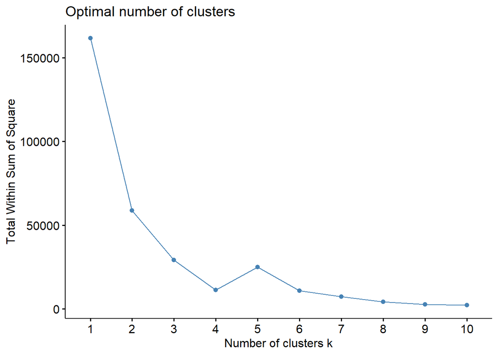

```r
fviz_nbclust(pizza_marka[,c(-1)], kmeans, method = "wss")
```

```r
set.seed(95739487)
km.res <- kmeans(pizza_marka[,c(-1)],4, iter.max=10, algorithm="Lloyd")
t(km.res$centers)
```

```
##                1         2          3          4
## mois   32.447333 29.966207 49.4656667 50.1034426
## prot    7.940333 20.107241 20.4098889 10.4791803
## ash     1.449167  5.014483  3.7125556  2.2380328
## sodium  0.442000  1.656207  0.7328889  0.5539344
## carb   42.816583  1.486897  3.4518889 22.4204918
## cal     3.413833  4.773793  3.0216667  2.6434426
## fat    15.343917 43.446897 22.9611111 14.7726230
```

### 2D Kümeleme Grafikleri

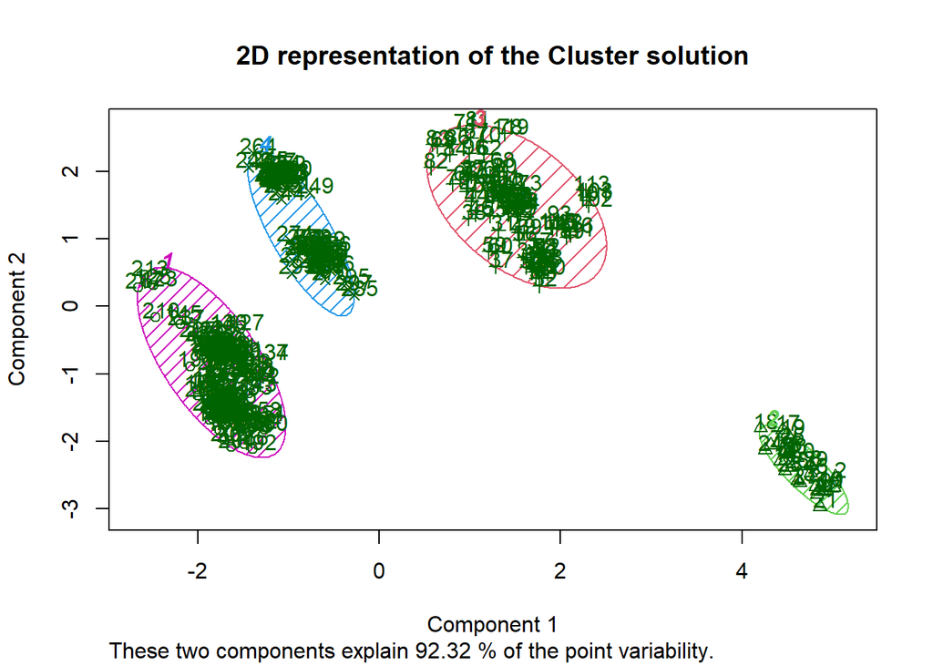

```r
library(cluster)
clusplot(pizza_marka[,c(-1)], km.res$cluster, main='2D representation of the Cluster solution',
         color=TRUE, shade=TRUE,
         labels=2, lines=0)
```

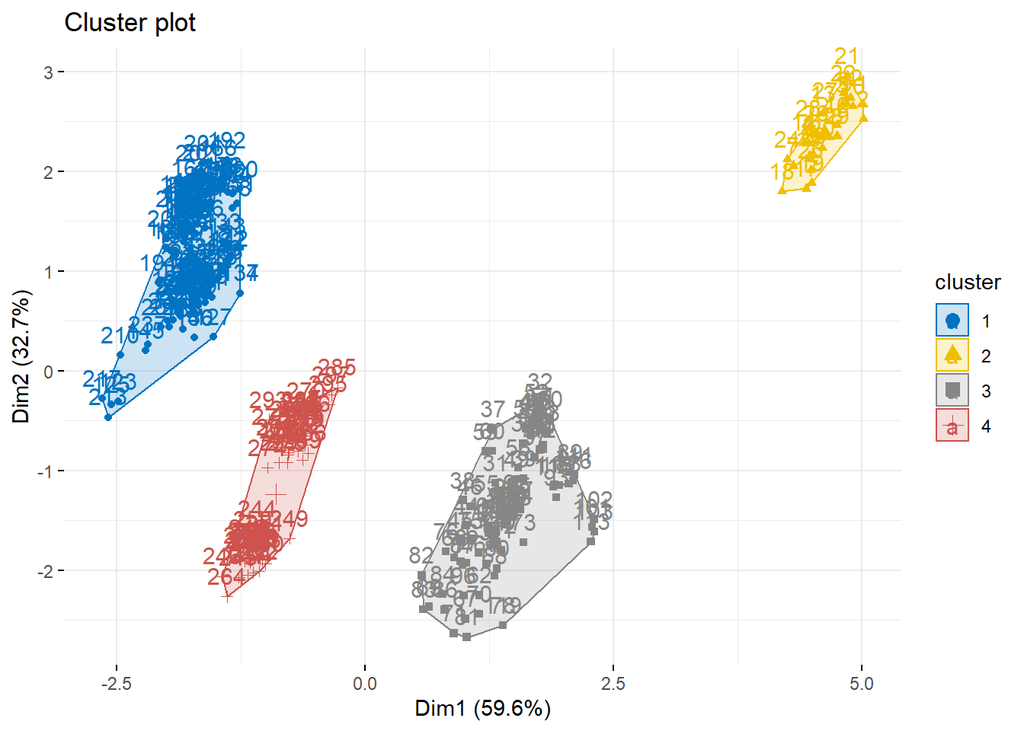

```r
fviz_cluster(km.res, data = pizza_marka[,c(-1)], palette = "jco",
             ggtheme = theme_minimal())
```

```r
pizza_marka$cluster<-km.res$cluster
pizza_marka$cluster<-as.factor(pizza_marka$cluster)
```

### ANOVA TABLOLARI

cal, sodium, fat ve carb değişkenlerimizin kümeleme bağlı ANOVA tabloları çıkarılmıştır.

```r
library(rstatix)

cal_aov <- aov(cal ~ cluster, data = pizza_marka)
summary(cal_aov)
```

```
##              Df Sum Sq Mean Sq F value Pr(>F)
## cluster       3  97.56   32.52   553.6 <2e-16 ***
## Residuals   296  17.39    0.06
## ---
## Signif. codes:  0 '***' 0.001 '**' 0.01 '*' 0.05 '.' 0.1 ' ' 1
```

```r
sodium_aov <- aov(sodium ~ cluster, data = pizza_marka)
summary(sodium_aov)
```

```
##              Df Sum Sq Mean Sq F value Pr(>F)
## cluster       3  35.62  11.874   651.9 <2e-16 ***
## Residuals   296   5.39   0.018
## ---
## Signif. codes:  0 '***' 0.001 '**' 0.01 '*' 0.05 '.' 0.1 ' ' 1
```

```r
fat_aov <- aov(fat ~ cluster, data = pizza_marka)
summary(fat_aov)
```

```
##              Df Sum Sq Mean Sq F value Pr(>F)
## cluster       3  20985    6995   667.1 <2e-16 ***
## Residuals   296   3104      10
## ---
## Signif. codes:  0 '***' 0.001 '**' 0.01 '*' 0.05 '.' 0.1 ' ' 1
```

```r
carb_aov <- aov(carb ~ cluster, data = pizza_marka)
summary(carb_aov)
```

```
##              Df Sum Sq Mean Sq F value Pr(>F)
## cluster       3  94952   31651    4174 <2e-16 ***
## Residuals   296   2244       8
## ---
## Signif. codes:  0 '***' 0.001 '**' 0.01 '*' 0.05 '.' 0.1 ' ' 1
```

> Tüm ANOVA tablolarını incelediğimizde P-value değerleri 0.05’ ten küçük olduğu için hepsi anlamlıdır ve kümelemlerin doğru yapıldığı söylenebilir.

# Kaynakça

> https://www.kaggle.com/shishir349/can-pizza-be-healthy